# Finding Molecules

Bob Turner

When reconstructing super resolved images from multiple frames of image data using single molecule localisation microscopy (e.g. PALM, STORM), the first challenge is often to locate regions of the frames where we expect to find images of molecules such that they can then be fitted to a model to determine their location. In this coding note, I’m going to go through the process of doing this. Several alterative approaches are available for many of the steps - this may not be how a particular piece of software e.g. NSTORM or ThunderSTORM tackles the problem, but it hopefully gives a general idea as to what’s going on under the hood.

If you have any comments or suggestions, please drop me a line at bob.turner.uk at gmail.com.

I’ve made use of ImageR - the associated documentation has lots of useful information on finding “blobs” in images https://cran.r-project.org/web/packages/imager/vignettes/gettingstarted.html.

## Load and display image

The first task is to load and display an image. I have used an example from EPFL’s Single Molecule Microscopy Software Benchmarking site http://bigwww.epfl.ch/smlm/challenge2013/datasets/Tubulins_I/index.html.

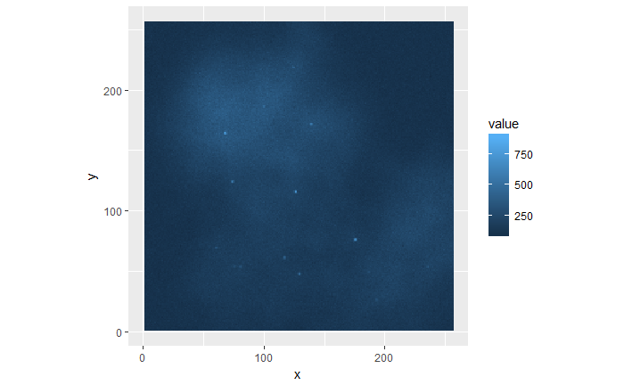

```r
library('raster')
library('imager')
image<-raster('sequence/00001.tif') %>% as.cimg()
ggplot(image %>% as.data.frame(),mapping=aes(x=x,y=y,fill=value))+
  geom_raster()+
  coord_fixed()
```

The small bright spots are the molecules that we’re interested in, but there is a lot of background partially obscuring them.

# Apply a filter to accentuate molecules

There are numerous approaches out there for filtering images - I’ve picked one that works well in my experience. The key point, I think, is that this filter accentuates features in the image that we are interested in, and facilitates further processing. The Gaussian blur element of the filter takes the paramater “2” as its standard deviation. This is linked to the size of the spots in the image - a bigger number would be used to match larger spots.

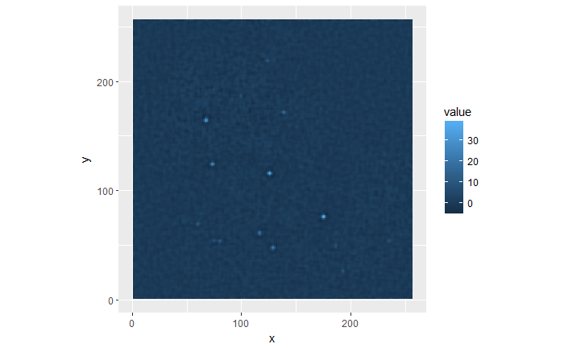

```r
image_LOG<--(isoblur(image, sigma = 2, gaussian = TRUE) %>% imlap())
ggplot(image_LOG %>% as.data.frame(),mapping=aes(x=x,y=y,fill=value))+
  geom_raster()+
  coord_fixed()
```

# Use a threshold to seperate signal and noise

The next step is to further supress noise by applying a threshold to the image. This restricts data to bright pixels. In practice, thresholds often need to be manually adjusted for different image data sets.

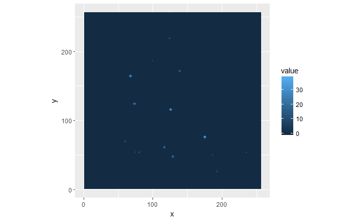

```r
image_bin<-threshold(image_LOG,'99.5%')
image_hi<-image_LOG*image_bin
ggplot(image_hi %>% as.data.frame(),mapping=aes(x=x,y=y,fill=value))+
  geom_raster()+
  coord_fixed()
```

# Find rough positions of molecules

In order to pin the spots down to single pixels, I’ve adapted a method that I’d prevously used with Matlab to find local maxima. This takes each pixel in the filtered, thresholded image and asks if it is brighter than the eight surrounding pixels. If it is, then it’s a candidate for fitting.

```r
reg_max <- function(region){

  #This function determines whether a patch of an image contains a local maximum, defined as a pixel that has a higher value than all of those surrounding it.
  #It needs a vector representing a square with odd numbered sides.
  #The idea is that this is passed to it by focal().

  side<-sqrt(length(region))

  region_2d <- matrix(region, nrow = side, byrow = TRUE)
  midpx<-ceiling(side/2)

  if(max(region)==min(region)) #Check if all values are the same - if so, it's not a local maximum.
    return(0)
  else
    if(region_2d[midpx, midpx]==max(region)) #Check if the central pixel has the highest value.
      return(1)
    else
      return(0)

}
```

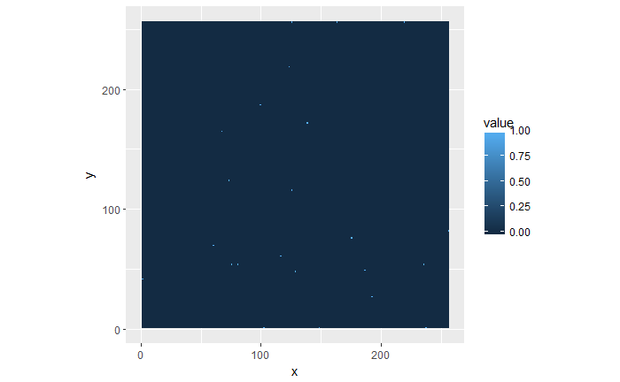

```r
weights <- matrix(1, 3, 3)
regional_maxima <- as.matrix(image_hi) %>% t() %>% raster() %>% focal(w=weights, fun=reg_max, pad=TRUE, padValue=0) %>% as.cimg()
ggplot(regional_maxima %>% as.data.frame(),mapping=aes(x=x,y=y,fill=value))+
  geom_raster()+
  coord_fixed()
```

# Create some square regions around the molecules

Once we have a set of bright pixels that represent the maxima of the spots, the next thing to do is to cut out squares of the image that would be passed to a fitting routine to obtain the super-resolved positions of the molecules. If these squares are too close together, or overlap the edge of the images, we want nothing more to do with them, so we exlcude them from further anlaysis. This is achieved by checking the area of the image patches - if it’s not equal to the size of our squares, we exclude.

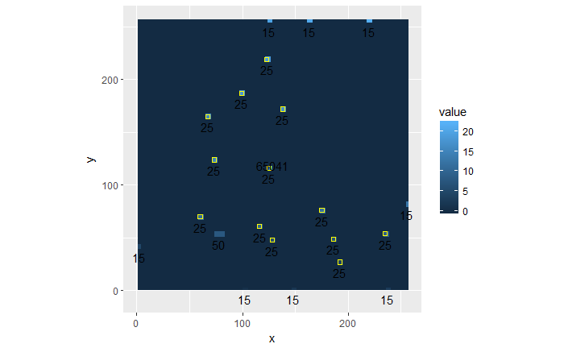

```r
square_side<-5
image_squares<-dilate_square(regional_maxima,square_side) %>% label()
data_frame_squares <- as.data.frame(image_squares)
library(dplyr)
summary_squares<-group_by(data_frame_squares, value) %>% summarise(mean_x=mean(x),mean_y=mean(y),min_x=min(x),max_x=max(x),min_y=min(y),max_y=max(y),n_px=n())
summary_good_squares<-summary_squares[summary_squares$n_px==square_side^2,]
ggplot()+
  geom_raster(data=data_frame_squares,mapping=aes(x=x,y=y,fill=value))+
  geom_rect(data=summary_good_squares, mapping=aes(xmin=min_x, xmax=max_x, ymin=min_y, ymax=max_y), color="yellow", fill=NA)+
  geom_text(data=summary_squares, aes(mean_x,mean_y,label=n_px), nudge_y = -10)+
  coord_fixed()
```

I’ve annotated the “squares” with their areas in pixels and highlighted those that will be included in further analysis.

## Visualise regions to be fitted

It is now possible to plot the locations of the square patches of the original image that we would fit to get a super resolved picture.

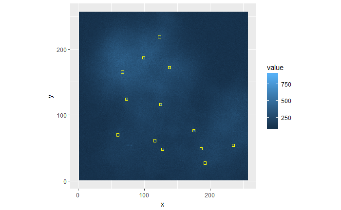

```r
data_frame_image<-as.data.frame(image)
ggplot()+
  geom_raster(data=data_frame_image,mapping=aes(x=x,y=y,fill=value))+
  geom_rect(data=summary_good_squares, mapping=aes(xmin=min_x, xmax=max_x, ymin=min_y, ymax=max_y), fill=NA, color="yellow")+
  coord_fixed()
```

```r
NA
```

And we can look at each of these in detail by associating the pixels in our original image with the sqaure patches.

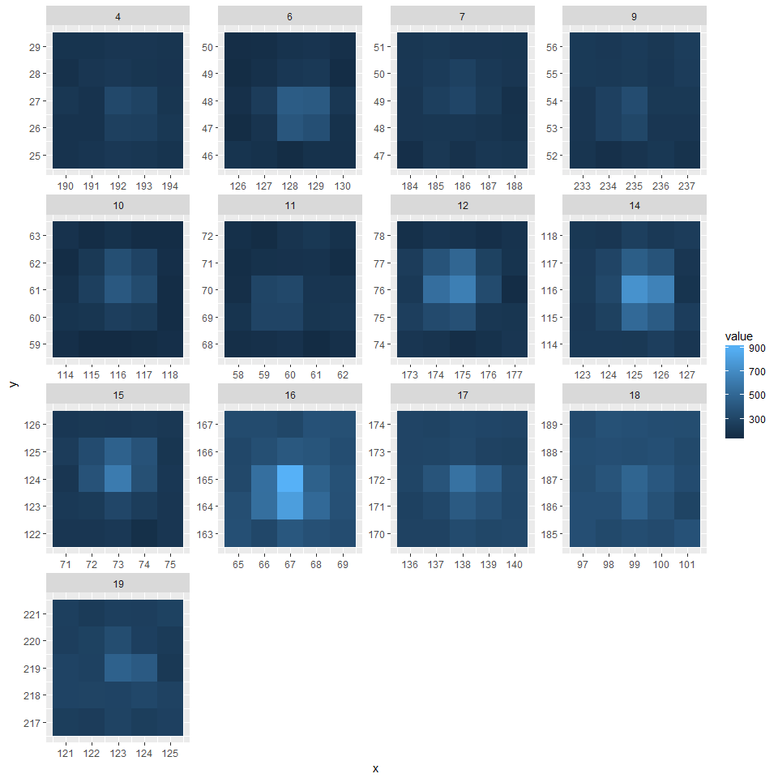

```r
data_frame_image$square_value<-data_frame_squares$value
data_to_fit<-merge(x = data_frame_image, y = summary_good_squares, by.x="square_value", by.y = "value", all.y = TRUE)
ggplot()+
  geom_tile(data=data_to_fit,mapping=aes(x=x,y=y,fill=value))+
  facet_wrap(~square_value, scales = "free")+
  coord_fixed()
```

At this stage we have produced a data frame (data_to_fit) with an indexed subset of the the image that needs to be fitted to a model in order to determine super resolved molecule locations.